# Reproducible Research: Peer Assessment 1

This Assignment tries to answer the following 4 questions:

1. What is mean total number of steps taken per day?
2. What is the average daily activity pattern
3. Imputing missing values
4. Are there differences in activity patterns between weekdays and weekends?

### Loading and processing the data

Here it is assumed that you have the downloaded the data and saved it in a zip file named “activity.zip” and is placed in the working directory.

```r
## Please note I have taken this course before
## Thus you might find a few things being replicated
## But I have tried to remove the previous repo and start a new.
## Thanks.
unzip("activity.zip", exdir = "activity")
datass <- read.csv("./activity/activity.csv"
                 , stringsAsFactors = FALSE)
datass$date <- as.character(datass$date)
datass$date <- as.Date(datass$date)
comdata <- datass[complete.cases(datass),]
```

### What is mean total number of steps taken per day?

For this part we were first required to make a histogram of the total number of steps taken each day

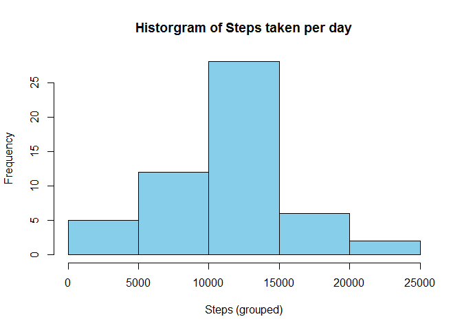

```r
p1 <- aggregate(steps~date, datass, sum)
hist(p1$steps, col= "skyblue", main = "Historgram of Steps taken per day", xlab= "Steps (grouped)")
```

```r
m <- mean(p1$steps)
m
```

```
## [1] 10766.19
```

The mean total number of steps taken per day is $1.0766189\times 10^{4}$

```r
md <- median(p1$steps)
md
```

```
## [1] 10765
```

The median total number of steps taken per day is $10765$

### What is the average daily activity pattern?

First we are required to make a time series plot (i.e. type = “l”) of the 5-minute interval (x-axis) and the average number of steps taken, averaged across all days (y-axis)

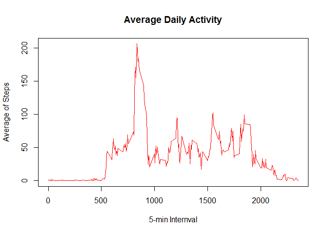

```r
p2 <- aggregate(steps ~ interval,comdata, mean)
plot(p2$interval, p2$steps, type="l", main = "Average Daily Activity", xlab = "5-min Internval", ylab = "Average of Steps", col = "red")
```

Then we are asked to get the 5-minute interval, on average across all the days in the dataset, which contains the maximum number of steps.

```r
maxint <-p2[which.max(p2$steps),1]
maxint
```

```
## [1] 835
```

Which is interval 835